# code

```python
import pandas as pd
import numpy as np
import matplotlib.pyplot as plt
import seaborn as sns
```

```python
data =  pd.read_csv(r"C:\Users\Admin\OneDrive\Desktop\DATASETS\NullClass\credit_card_transactions.csv")
data.head()
```

|  | Unnamed: 0 | trans_date_trans_time | cc_num | merchant | category | amt | first | last | gender | street | ... | long | city_pop | job | dob | trans_num | unix_time | merch_lat | merch_long | is_fraud | merch_zipcode |
| --- | --- | --- | --- | --- | --- | --- | --- | --- | --- | --- | --- | --- | --- | --- | --- | --- | --- | --- | --- | --- | --- |
| 0 | 0 | 2019-01-01 00:00:18 | 2703186189652095 | fraud_Rippin, Kub and Mann | misc_net | 4.97 | Jennifer | Banks | F | 561 Perry Cove | ... | -81.1781 | 3495 | Psychologist, counselling | 1988-03-09 | 0b242abb623afc578575680df30655b9 | 1325376018 | 36.011293 | -82.048315 | 0 | 28705.0 |
| 1 | 1 | 2019-01-01 00:00:44 | 630423337322 | fraud_Heller, Gutmann and Zieme | grocery_pos | 107.23 | Stephanie | Gill | F | 43039 Riley Greens Suite 393 | ... | -118.2105 | 149 | Special educational needs teacher | 1978-06-21 | 1f76529f8574734946361c461b024d99 | 1325376044 | 49.159047 | -118.186462 | 0 | NaN |
| 2 | 2 | 2019-01-01 00:00:51 | 38859492057661 | fraud_Lind-Buckridge | entertainment | 220.11 | Edward | Sanchez | M | 594 White Dale Suite 530 | ... | -112.2620 | 4154 | Nature conservation officer | 1962-01-19 | a1a22d70485983eac12b5b88dad1cf95 | 1325376051 | 43.150704 | -112.154481 | 0 | 83236.0 |
| 3 | 3 | 2019-01-01 00:01:16 | 3534093764340240 | fraud_Kutch, Hermiston and Farrell | gas_transport | 45.00 | Jeremy | White | M | 9443 Cynthia Court Apt. 038 | ... | -112.1138 | 1939 | Patent attorney | 1967-01-12 | 6b849c168bdad6f867558c3793159a81 | 1325376076 | 47.034331 | -112.561071 | 0 | NaN |
| 4 | 4 | 2019-01-01 00:03:06 | 375534208663984 | fraud_Keeling-Crist | misc_pos | 41.96 | Tyler | Garcia | M | 408 Bradley Rest | ... | -79.4629 | 99 | Dance movement psychotherapist | 1986-03-28 | a41d7549acf90789359a9aa5346dcb46 | 1325376186 | 38.674999 | -78.632459 | 0 | 22844.0 |

5 rows × 24 columns

```python
data.isnull().sum()
```

```
Unnamed: 0                    0
trans_date_trans_time         0
cc_num                        0
merchant                      0
category                      0
amt                           0
first                         0
last                          0
gender                        0
street                        0
city                          0
state                         0
zip                           0
lat                           0
long                          0
city_pop                      0
job                           0
dob                           0
trans_num                     0
unix_time                     0
merch_lat                     0
merch_long                    0
is_fraud                      0
merch_zipcode            195973
dtype: int64
```

```python
data['merch_zipcode'].dtype
```

```
dtype('float64')
```

```python
data['merch_zipcode'].isnull().sum()
```

```
np.int64(195973)
```

```python
data.dropna(axis=1, how='any', inplace=True)
```

```python
data.head(3)
```

|  | Unnamed: 0 | trans_date_trans_time | cc_num | merchant | category | amt | first | last | gender | street | ... | lat | long | city_pop | job | dob | trans_num | unix_time | merch_lat | merch_long | is_fraud |
| --- | --- | --- | --- | --- | --- | --- | --- | --- | --- | --- | --- | --- | --- | --- | --- | --- | --- | --- | --- | --- | --- |
| 0 | 0 | 2019-01-01 00:00:18 | 2703186189652095 | fraud_Rippin, Kub and Mann | misc_net | 4.97 | Jennifer | Banks | F | 561 Perry Cove | ... | 36.0788 | -81.1781 | 3495 | Psychologist, counselling | 1988-03-09 | 0b242abb623afc578575680df30655b9 | 1325376018 | 36.011293 | -82.048315 | 0 |
| 1 | 1 | 2019-01-01 00:00:44 | 630423337322 | fraud_Heller, Gutmann and Zieme | grocery_pos | 107.23 | Stephanie | Gill | F | 43039 Riley Greens Suite 393 | ... | 48.8878 | -118.2105 | 149 | Special educational needs teacher | 1978-06-21 | 1f76529f8574734946361c461b024d99 | 1325376044 | 49.159047 | -118.186462 | 0 |
| 2 | 2 | 2019-01-01 00:00:51 | 38859492057661 | fraud_Lind-Buckridge | entertainment | 220.11 | Edward | Sanchez | M | 594 White Dale Suite 530 | ... | 42.1808 | -112.2620 | 4154 | Nature conservation officer | 1962-01-19 | a1a22d70485983eac12b5b88dad1cf95 | 1325376051 | 43.150704 | -112.154481 | 0 |

3 rows × 23 columns

```python
data.info
```

```
<bound method DataFrame.info of          Unnamed: 0 trans_date_trans_time               cc_num  \
0                 0   2019-01-01 00:00:18     2703186189652095
1                 1   2019-01-01 00:00:44         630423337322
2                 2   2019-01-01 00:00:51       38859492057661
3                 3   2019-01-01 00:01:16     3534093764340240
4                 4   2019-01-01 00:03:06      375534208663984
...             ...                   ...                  ...
1296670     1296670   2020-06-21 12:12:08       30263540414123
1296671     1296671   2020-06-21 12:12:19     6011149206456997
1296672     1296672   2020-06-21 12:12:32     3514865930894695
1296673     1296673   2020-06-21 12:13:36     2720012583106919
1296674     1296674   2020-06-21 12:13:37  4292902571056973207

                                    merchant       category     amt  \
0                 fraud_Rippin, Kub and Mann       misc_net    4.97
```

[output cut: 64 more lines]

```python
data.columns
```

```
Index(['Unnamed: 0', 'trans_date_trans_time', 'cc_num', 'merchant', 'category',
       'amt', 'first', 'last', 'gender', 'street', 'city', 'state', 'zip',
       'lat', 'long', 'city_pop', 'job', 'dob', 'trans_num', 'unix_time',
       'merch_lat', 'merch_long', 'is_fraud'],
      dtype='object')
```

```python
data['trans_date_trans_time'].describe()
```

```
count                 1296675
unique                1274791
top       2019-04-22 16:02:01
freq                        4
Name: trans_date_trans_time, dtype: object
```

```python
data['trans_date_trans_time'] = pd.to_datetime(data['trans_date_trans_time'])
data['trans_date_trans_time'].dtype
```

```
dtype('<M8[ns]')
```

```python
data['year'] = data['trans_date_trans_time'].dt.year
data['date'] = data['trans_date_trans_time'].dt.date
data['time'] = data['trans_date_trans_time'].dt.time
data['month'] = data['trans_date_trans_time'].dt.month
data['day'] = data['trans_date_trans_time'].dt.day
data['hour'] = data['trans_date_trans_time'].dt.hour
data['dayofweek'] = data['trans_date_trans_time'].dt.dayofweek
```

```python
data.head()
```

|  | Unnamed: 0 | trans_date_trans_time | cc_num | merchant | category | amt | first | last | gender | street | ... | merch_lat | merch_long | is_fraud | year | date | time | month | day | hour | dayofweek |
| --- | --- | --- | --- | --- | --- | --- | --- | --- | --- | --- | --- | --- | --- | --- | --- | --- | --- | --- | --- | --- | --- |
| 0 | 0 | 2019-01-01 00:00:18 | 2703186189652095 | fraud_Rippin, Kub and Mann | misc_net | 4.97 | Jennifer | Banks | F | 561 Perry Cove | ... | 36.011293 | -82.048315 | 0 | 2019 | 2019-01-01 | 00:00:18 | 1 | 1 | 0 | 1 |
| 1 | 1 | 2019-01-01 00:00:44 | 630423337322 | fraud_Heller, Gutmann and Zieme | grocery_pos | 107.23 | Stephanie | Gill | F | 43039 Riley Greens Suite 393 | ... | 49.159047 | -118.186462 | 0 | 2019 | 2019-01-01 | 00:00:44 | 1 | 1 | 0 | 1 |
| 2 | 2 | 2019-01-01 00:00:51 | 38859492057661 | fraud_Lind-Buckridge | entertainment | 220.11 | Edward | Sanchez | M | 594 White Dale Suite 530 | ... | 43.150704 | -112.154481 | 0 | 2019 | 2019-01-01 | 00:00:51 | 1 | 1 | 0 | 1 |
| 3 | 3 | 2019-01-01 00:01:16 | 3534093764340240 | fraud_Kutch, Hermiston and Farrell | gas_transport | 45.00 | Jeremy | White | M | 9443 Cynthia Court Apt. 038 | ... | 47.034331 | -112.561071 | 0 | 2019 | 2019-01-01 | 00:01:16 | 1 | 1 | 0 | 1 |
| 4 | 4 | 2019-01-01 00:03:06 | 375534208663984 | fraud_Keeling-Crist | misc_pos | 41.96 | Tyler | Garcia | M | 408 Bradley Rest | ... | 38.674999 | -78.632459 | 0 | 2019 | 2019-01-01 | 00:03:06 | 1 | 1 | 0 | 1 |

5 rows × 30 columns

```python
print(f"Time range: {data['trans_date_trans_time'].min()} to {data['trans_date_trans_time'].max()}")
```

```
Time range: 2019-01-01 00:00:18 to 2020-06-21 12:13:37
```

```python
duplicates = data[data.duplicated(subset=['trans_date_trans_time'], keep=False)]
print(f"Number of duplicate timestamps: {len(duplicates)}")
```

```
Number of duplicate timestamps: 43457
```

```python
duplicates
```

|  | Unnamed: 0 | trans_date_trans_time | cc_num | merchant | category | amt | first | last | gender | street | ... | merch_lat | merch_long | is_fraud | year | date | time | month | day | hour | dayofweek |
| --- | --- | --- | --- | --- | --- | --- | --- | --- | --- | --- | --- | --- | --- | --- | --- | --- | --- | --- | --- | --- | --- |
| 43 | 43 | 2019-01-01 00:32:15 | 30074693890476 | fraud_Lockman Ltd | grocery_pos | 212.75 | Kelsey | Richards | F | 889 Sarah Station Suite 624 | ... | 38.862183 | -101.234087 | 0 | 2019 | 2019-01-01 | 00:32:15 | 1 | 1 | 0 | 1 |
| 44 | 44 | 2019-01-01 00:32:15 | 180067784565096 | fraud_Koepp-Witting | grocery_pos | 130.40 | Mary | Juarez | F | 35440 Ryan Islands | ... | 42.236269 | -88.397336 | 0 | 2019 | 2019-01-01 | 00:32:15 | 1 | 1 | 0 | 1 |
| 92 | 92 | 2019-01-01 01:09:57 | 3502088871723054 | fraud_Padberg-Welch | grocery_pos | 50.57 | Scott | Martin | M | 31472 Cody Place Suite 740 | ... | 38.394608 | -76.437916 | 0 | 2019 | 2019-01-01 | 01:09:57 | 1 | 1 | 1 | 1 |
| 93 | 93 | 2019-01-01 01:09:57 | 180048185037117 | fraud_Rippin, Kub and Mann | misc_net | 3.79 | Mary | Wall | F | 2481 Mills Lock | ... | 40.813669 | -75.283465 | 0 | 2019 | 2019-01-01 | 01:09:57 | 1 | 1 | 1 | 1 |
| 96 | 96 | 2019-01-01 01:14:11 | 4423489490781412 | fraud_Huels-Nolan | gas_transport | 50.61 | Christopher | Ortega | M | 5045 Emily Wall | ... | 41.027284 | -89.416172 | 0 | 2019 | 2019-01-01 | 01:14:11 | 1 | 1 | 1 | 1 |
| ... | ... | ... | ... | ... | ... | ... | ... | ... | ... | ... | ... | ... | ... | ... | ... | ... | ... | ... | ... | ... | ... |
| 1296477 | 1296477 | 2020-06-21 10:32:03 | 4653178848915023204 | fraud_Cummerata-Jones | gas_transport | 76.02 | Robert | Hall | M | 371 Anthony Trail Suite 354 | ... | 37.298764 | -80.885145 | 0 | 2020 | 2020-06-21 | 10:32:03 | 6 | 21 | 10 | 6 |
| 1296526 | 1296526 | 2020-06-21 10:58:26 | 377654590313960 | fraud_Cartwright-Harris | grocery_pos | 77.74 | Lawrence | Davis | M | 7421 Serrano Lane Apt. 580 | ... | 35.826986 | -83.783989 | 0 | 2020 | 2020-06-21 | 10:58:26 | 6 | 21 | 10 | 6 |
| 1296527 | 1296527 | 2020-06-21 10:58:26 | 4302475216404898 | fraud_Howe PLC | entertainment | 9.05 | Daniel | Cain | M | 384 Newman Forks Apt. 370 | ... | 43.801312 | -94.531817 | 0 | 2020 | 2020-06-21 | 10:58:26 | 6 | 21 | 10 | 6 |
| 1296622 | 1296622 | 2020-06-21 11:48:51 | 4503101193493052864 | fraud_Rempel PLC | grocery_net | 56.29 | Katherine | Tucker | F | 670 Le Meadows Suite 250 | ... | 27.762157 | -82.045886 | 0 | 2020 | 2020-06-21 | 11:48:51 | 6 | 21 | 11 | 6 |
| 1296623 | 1296623 | 2020-06-21 11:48:51 | 30030380240193 | fraud_Wiza, Schaden and Stark | misc_pos | 38.81 | William | Jenkins | M | 50614 Kevin Point | ... | 30.050475 | -98.546907 | 0 | 2020 | 2020-06-21 | 11:48:51 | 6 | 21 | 11 | 6 |

43457 rows × 30 columns

```python
# Count fraudulent transactions for each day of the week
fraud_by_day = data[data['is_fraud'] == 1]['dayofweek'].value_counts().sort_index()

# Count total transactions for each day of the week
total_by_day = data['dayofweek'].value_counts().sort_index()

# Calculate the proportion of fraudulent transactions per day of the week
fraud_proportion = fraud_by_day / total_by_day

print("Fraudulent Transaction Counts by Day of Week:")
print(fraud_by_day)

print("\nTotal Transaction Counts by Day of Week:")
print(total_by_day)

print("\nProportion of Fraudulent Transactions by Day of Week:")
print(fraud_proportion)
```

```
Fraudulent Transaction Counts by Day of Week:
dayofweek
0    1182
1     935
2     859
3    1008
4    1079
5    1227
6    1216
Name: count, dtype: int64

Total Transaction Counts by Day of Week:
dayofweek
0    254282
1    160227
2    131073
3    147285
4    152272
5    200957
6    250579
Name: count, dtype: int64

Proportion of Fraudulent Transactions by Day of Week:
dayofweek
0    0.004648
1    0.005835
2    0.006554
3    0.006844
4    0.007086
5    0.006106
6    0.004853
Name: count, dtype: float64
```

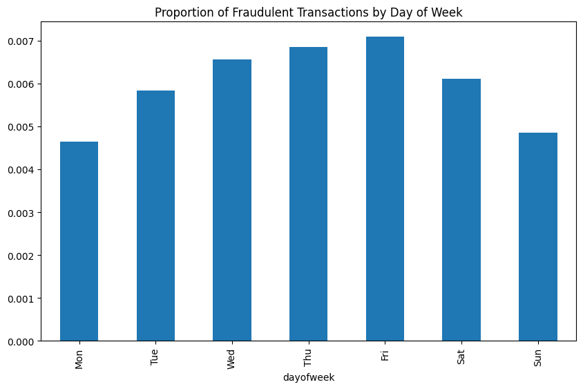

```python
fraud_proportion.plot(kind='bar', figsize=(10,6), title='Proportion of Fraudulent Transactions by Day of Week')
plt.xticks(range(7), ['Mon', 'Tue', 'Wed', 'Thu', 'Fri', 'Sat', 'Sun'])
plt.show()
```

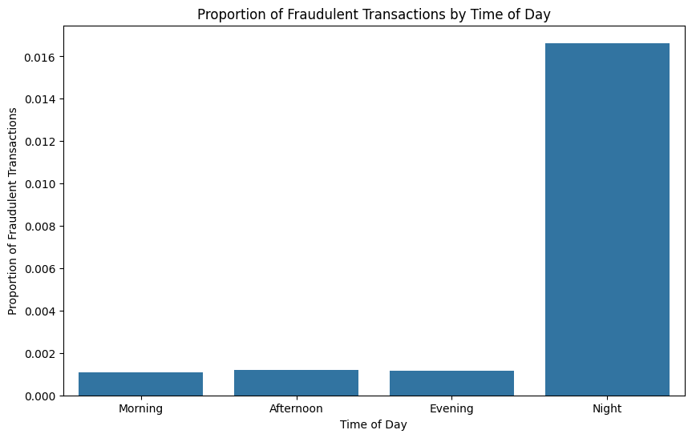

```python
# Assuming your DataFrame is named 'data' and 'trans_date_trans_time' is already converted to datetime

# Extract the hour from the datetime column
data['hour'] = data['trans_date_trans_time'].dt.hour

# Define time of day categories
def categorize_time(hour):
    if 6 <= hour < 12:
        return 'Morning'
    elif 12 <= hour < 17:
        return 'Afternoon'
    elif 17 <= hour < 22:
        return 'Evening'
    else:
        return 'Night'

# Apply the categorization function
data['time_of_day'] = data['hour'].apply(categorize_time)

# Count fraudulent transactions for each time of day
fraud_by_time = data[data['is_fraud'] == 1]['time_of_day'].value_counts()

# Count total transactions for each time of day
total_by_time = data['time_of_day'].value_counts()

# Calculate the proportion of fraudulent transactions per time of day
fraud_proportion_time = fraud_by_time / total_by_time

# Plot the proportion of fraudulent transactions by time of day
plt.figure(figsize=(10, 6))
sns.barplot(x=fraud_proportion_time.index, y=fraud_proportion_time.values, order=['Morning', 'Afternoon', 'Evening', 'Night'])
plt.title('Proportion of Fraudulent Transactions by Time of Day')
plt.xlabel('Time of Day')
plt.ylabel('Proportion of Fraudulent Transactions')
plt.show()
```

The counts show variations in the number of fraudulent transactions across the week. Observations: Saturday (5) and Sunday (6) have the highest number of fraudulent transactions.

Implications: This suggests that fraudsters may be more active on weekends. It's worth investigating why this might be the case. It could be due to: Increased transaction volume on weekends. Less stringent security measures on weekends. Fraudsters taking advantage of reduced staffing or monitoring. "Most frauds occurred at night"

This is a very important piece of information. Combining this with the day of week information, it means that the highest amount of fraud is happening on the weekends, during the night time.

```python
data.columns
```

```
Index(['Unnamed: 0', 'trans_date_trans_time', 'cc_num', 'merchant', 'category',
       'amt', 'first', 'last', 'gender', 'street', 'city', 'state', 'zip',
       'lat', 'long', 'city_pop', 'job', 'dob', 'trans_num', 'unix_time',
       'merch_lat', 'merch_long', 'is_fraud', 'year', 'date', 'time', 'month',
       'day', 'hour', 'dayofweek', 'time_of_day'],
      dtype='object')
```

```python
data.cc_num.value_counts()
```

```
cc_num
4512828414983801773    3123
571365235126           3123
36722699017270         3119
213112402583773        3117
3545109339866548       3113
                       ...
180097223252063           7
340187018810220           7
501894933032              7
4975457191020             7
3545578418030657          7
Name: count, Length: 983, dtype: int64
```

```python
data['cc_num'].nunique()
```

```
983
```

```python
data['cc_num'].value_counts()
```

```
cc_num
4512828414983801773    3123
571365235126           3123
36722699017270         3119
213112402583773        3117
3545109339866548       3113
                       ...
180097223252063           7
340187018810220           7
501894933032              7
4975457191020             7
3545578418030657          7
Name: count, Length: 983, dtype: int64
```

```python
len(data['cc_num'])
```

```
1296675
```

```python
data['cc_num'].unique()
```

```
array([   2703186189652095,        630423337322,      38859492057661,
          3534093764340240,     375534208663984,    4767265376804500,
            30074693890476,    6011360759745864,    4922710831011201,
          2720830304681674,       4642894980163,     377234009633447,
           180042946491150,    5559857416065248,    3514865930894695,
          6011999606625827,    6011860238257910,    3565423334076143,
          2348245054386329, 4956828990005111019, 4469777115158234880,
          2305336922781618,     180048185037117,        630441765090,
       4428780983793657331,     343464013864032,     374930071163758,
          4334230547694630, 4225990116481262579,    4260059589824237,
           180094608895855, 4599735407877245080,        630412733309,
          2712209726293386,     374125201044065,     349612764943496,
          3598215285024754,     213141712584544,      30561214688470,
          4789911625179723,        676372984911,      30011465039817,
          4642255475285942,     180067784565096,     213126662687660,
```

[output cut: 313 more lines]

Customer Behavior: This column can be used to analyze customer spending patterns. You can group transactions by credit card number to see how often each card is used, the average transaction amount, etc.

Fraud Detection: Analyzing transaction patterns for individual credit cards can be extremely useful. For example, sudden changes in spending habits, unusual transaction locations, or rapid sequences of transactions might indicate fraud.

```python
# Assuming your DataFrame is named 'data'

# Number of transactions per credit card
transactions_per_card = data['cc_num'].value_counts().reset_index()
transactions_per_card.columns = ['cc_num', 'num_transactions']
data = pd.merge(data, transactions_per_card, on='cc_num', how='left')

# Average transaction amount per credit card
avg_amount_per_card = data.groupby('cc_num')['amt'].mean().reset_index()
avg_amount_per_card.columns = ['cc_num', 'avg_transaction_amount']
data = pd.merge(data, avg_amount_per_card, on='cc_num', how='left')

# Example of time between transactions.
# This requires the data to be sorted by time, and then grouped by cc_num.
# Then the diff function can be used.

print(data[['cc_num', 'num_transactions', 'avg_transaction_amount']].head())
```

```
             cc_num  num_transactions  avg_transaction_amount
0  2703186189652095              2028               87.393215
1      630423337322              3030               53.949320
2    38859492057661               503               65.870040
3  3534093764340240               493               72.776673
4   375534208663984              2017               95.178091
```

Correlation Analysis: Calculate the correlation between these features and the is_fraud column.

```python
# Calculate the correlation matrix
correlation_matrix = data[['num_transactions', 'avg_transaction_amount', 'is_fraud']].corr()

# Print the correlation matrix
print(correlation_matrix)

# Alternatively, you can print just the correlation with 'is_fraud'
print("\nCorrelation with 'is_fraud':")
print(correlation_matrix['is_fraud'])
```

```
                        num_transactions  avg_transaction_amount  is_fraud
num_transactions                1.000000               -0.086312 -0.054882
avg_transaction_amount         -0.086312                1.000000  0.209960
is_fraud                       -0.054882                0.209960  1.000000

Correlation with 'is_fraud':
num_transactions         -0.054882
avg_transaction_amount    0.209960
is_fraud                  1.000000
Name: is_fraud, dtype: float64
```

Implications:

The weak positive correlation with avg_transaction_amount suggests that this feature might have some predictive power for fraud detection. High average transaction amounts could be a red flag. The very weak negative correlation of num_transactions means that this feature by itself is not a strong predictor of fraud.

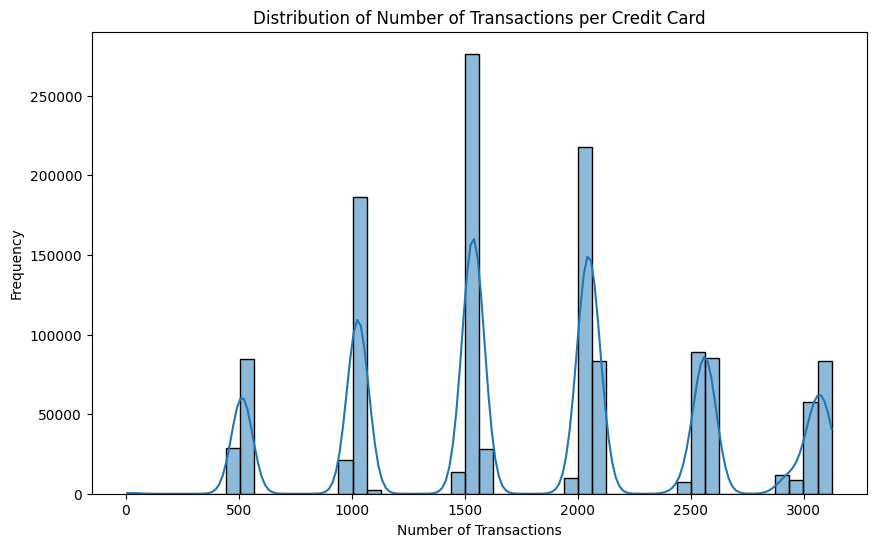

```python
plt.figure(figsize=(10, 6))
sns.histplot(data['num_transactions'], bins=50, kde=True)
plt.title('Distribution of Number of Transactions per Credit Card')
plt.xlabel('Number of Transactions')
plt.ylabel('Frequency')
plt.show()
```

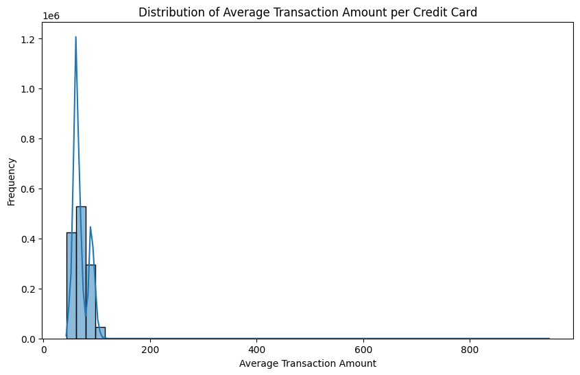

```python
plt.figure(figsize=(10, 6))
sns.histplot(data['avg_transaction_amount'], bins=50, kde=True)
plt.title('Distribution of Average Transaction Amount per Credit Card')
plt.xlabel('Average Transaction Amount')
plt.ylabel('Frequency')
plt.show()
```

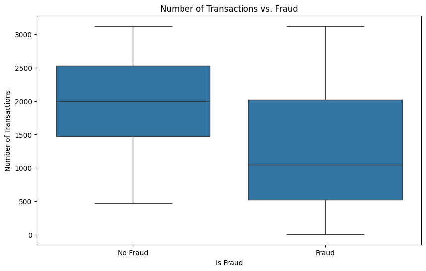

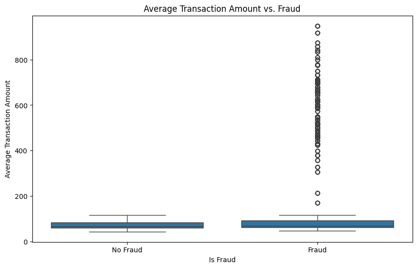

```python
plt.figure(figsize=(10, 6))
sns.boxplot(x='is_fraud', y='num_transactions', data=data)
plt.title('Number of Transactions vs. Fraud')
plt.xlabel('Is Fraud')
plt.ylabel('Number of Transactions')
plt.xticks([0, 1], ['No Fraud', 'Fraud'])
plt.show()

plt.figure(figsize=(10, 6))
sns.boxplot(x='is_fraud', y='avg_transaction_amount', data=data)
plt.title('Average Transaction Amount vs. Fraud')
plt.xlabel('Is Fraud')
plt.ylabel('Average Transaction Amount')
plt.xticks([0, 1], ['No Fraud', 'Fraud'])
plt.show()
```

```python
# Count Occurrences
card_counts = data['cc_num'].value_counts()

# Identify Frequent Cards (e.g., cards appearing more than 1000 times)
frequent_cards = card_counts[card_counts > 1000]  # Adjust threshold as needed

# Print the frequent cards and their counts
print("Frequent Credit Card Numbers:")
print(frequent_cards)

# Calculate the fraud rate for the frequent cards.
frequent_card_fraud_rates = data[data['cc_num'].isin(frequent_cards.index)].groupby('cc_num')['is_fraud'].mean()

# Print the fraud rates for the frequent cards.
print("\nFraud Rates for Frequent Credit Card Numbers:")
print(frequent_card_fraud_rates)

# Investigate other characteristics of frequent cards (e.g., categories, merchants)
frequent_card_data = data[data['cc_num'].isin(frequent_cards.index)]

print("\nCategory Distribution for Frequent Credit Card Numbers:")
print(frequent_card_data['category'].value_counts(normalize=True))

print("\nMerchant Distribution for Frequent Credit Card Numbers:")
print(frequent_card_data['merchant'].value_counts().head(10)) # Top 10 Merchants
```

```
Frequent Credit Card Numbers:
cc_num
4512828414983801773    3123
571365235126           3123
36722699017270         3119
213112402583773        3117
3545109339866548       3113
                       ...
370818583810103        1002
4788103653396          1002
4063094974360571498    1001
4839043708100390       1001
3598014571045296       1001
Name: count, Length: 675, dtype: int64

Fraud Rates for Frequent Credit Card Numbers:
cc_num
60416207185            0.005929
60422928733            0.007838
60490596305            0.009901
501802953619           0.004490
501831082224           0.007797
                         ...
4956828990005111019    0.003897
4958589671582726883    0.000000
4973530368125489546    0.009615
4989847570577635369    0.000000
4992346398065154184    0.003885
Name: is_fraud, Length: 675, dtype: float64

Category Distribution for Frequent Credit Card Numbers:
category
gas_transport     0.101517
grocery_pos       0.094945
home              0.094911
shopping_pos      0.090013
kids_pets         0.087063
shopping_net      0.075486
entertainment     0.072394
food_dining       0.070475
personal_care     0.069855
health_fitness    0.066347
misc_pos          0.061509
misc_net          0.048862
grocery_net       0.035724
travel            0.030899
Name: proportion, dtype: float64

Merchant Distribution for Frequent Credit Card Numbers:
merchant
fraud_Kilback LLC               3949
fraud_Cormier LLC               3315
fraud_Schumm PLC                3314
fraud_Boyer PLC                 3137
fraud_Kuhn LLC                  3130
fraud_Dickinson Ltd             3087
fraud_Rodriguez Group           2492
fraud_Kutch LLC                 2475
fraud_Olson, Becker and Koch    2456
fraud_Erdman-Kertzmann          2448
Name: count, dtype: int64
```

Frequent Credit Card Numbers:

The truncated output shows that the fraud rates for frequent credit card numbers vary. Some have relatively low fraud rates, while others have higher rates.

Credit card numbers with fraud rates significantly higher than the overall rate are potential red flags.

The truncated output shows that merchants like "fraud_Kilback LLC," "fraud_Kuhn LLC," and others are frequently associated with transactions made using frequent credit card numbers.

Key Takeaways:

Certain credit card numbers are used very frequently. Fraud rates vary among these frequent credit card numbers. Frequent credit card numbers are associated with specific categories and merchants.

```
High-Risk Credit Card Numbers (Fraud Rate > Overall Rate):
Series([], Name: is_fraud, dtype: float64)

Fraud Rate Difference (Frequent Cards - Overall Rate):
cc_num
60416207185           -0.574071
60422928733           -0.572162
60490596305           -0.570099
501802953619          -0.575510
501831082224          -0.572203
                         ...
4956828990005111019   -0.576103
4958589671582726883   -0.580000
4973530368125489546   -0.570385
4989847570577635369   -0.580000
4992346398065154184   -0.576115
Name: is_fraud, Length: 675, dtype: float64
```

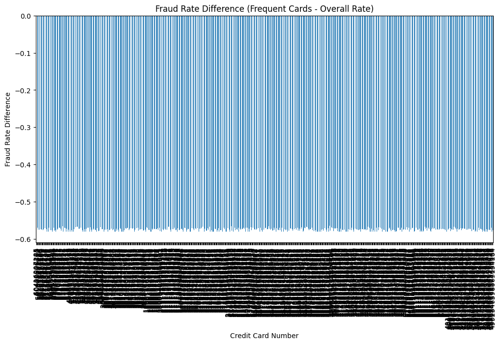

```python
# Compare fraud rates to the overall rate
overall_fraud_rate = 0.58
high_risk_cards = frequent_card_fraud_rates[frequent_card_fraud_rates > overall_fraud_rate]

# Print high-risk cards and their fraud rates
print("High-Risk Credit Card Numbers (Fraud Rate > Overall Rate):")
print(high_risk_cards)

# Calculate the difference between fraud rates and the overall rate
fraud_rate_difference = frequent_card_fraud_rates - overall_fraud_rate

# Print the differences
print("\nFraud Rate Difference (Frequent Cards - Overall Rate):")
print(fraud_rate_difference)

# Visualize the comparison (e.g., using a bar chart)
fraud_rate_difference.plot(kind='bar', figsize=(12, 6))
plt.title('Fraud Rate Difference (Frequent Cards - Overall Rate)')
plt.xlabel('Credit Card Number')
plt.ylabel('Fraud Rate Difference')
plt.show()
```

High-Risk Credit Card Numbers (Fraud Rate > Overall Rate):

Fraud Rate Difference (Frequent Cards - Overall Rate):

```python
data.columns
```

```
Index(['Unnamed: 0', 'trans_date_trans_time', 'cc_num', 'merchant', 'category',
       'amt', 'first', 'last', 'gender', 'street', 'city', 'state', 'zip',
       'lat', 'long', 'city_pop', 'job', 'dob', 'trans_num', 'unix_time',
       'merch_lat', 'merch_long', 'is_fraud', 'year', 'date', 'time', 'month',
       'day', 'hour', 'dayofweek', 'time_of_day', 'num_transactions',
       'avg_transaction_amount'],
      dtype='object')
```

```python
data['merchant'].describe()
```

```
count               1296675
unique                  693
top       fraud_Kilback LLC
freq                   4403
Name: merchant, dtype: object
```

```python
data['merchant'].value_counts()
```

```
merchant
fraud_Kilback LLC                       4403
fraud_Cormier LLC                       3649
fraud_Schumm PLC                        3634
fraud_Kuhn LLC                          3510
fraud_Boyer PLC                         3493
                                        ...
fraud_Douglas, DuBuque and McKenzie      775
fraud_Treutel-King                       775
fraud_Medhurst, Labadie and Gottlieb     759
fraud_Reichert-Weissnat                  753
fraud_Hahn, Douglas and Schowalter       727
Name: count, Length: 693, dtype: int64
```

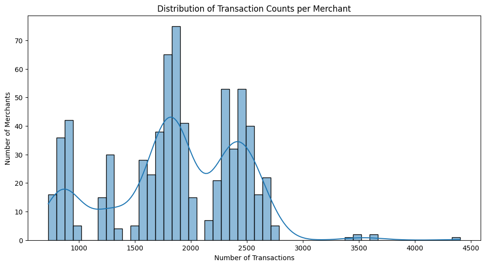

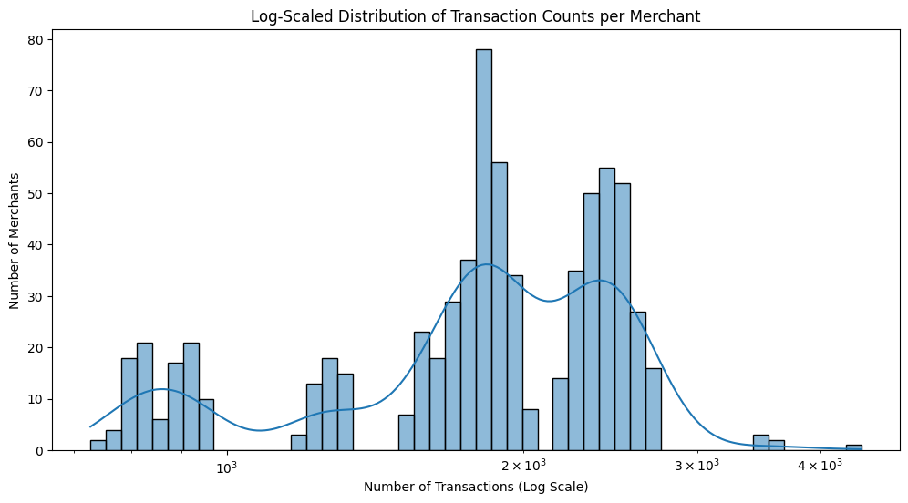

```python
# Count transactions per merchant
merchant_counts = data['merchant'].value_counts()

# Plot the distribution
plt.figure(figsize=(12, 6))
sns.histplot(merchant_counts, bins=50, kde=True)
plt.title('Distribution of Transaction Counts per Merchant')
plt.xlabel('Number of Transactions')
plt.ylabel('Number of Merchants')
plt.show()

# If you want to see a log-scaled distribution, which can be useful for highly skewed data:
plt.figure(figsize=(12, 6))
sns.histplot(merchant_counts, bins=50, kde=True, log_scale=True)
plt.title('Log-Scaled Distribution of Transaction Counts per Merchant')
plt.xlabel('Number of Transactions (Log Scale)')
plt.ylabel('Number of Merchants')
plt.show()
```

```python
# Count transactions per merchant
merchant_counts = data['merchant'].value_counts()

# Identify the two main peaks (approximate ranges from the histogram)
peak1_range = (800, 1200)
peak2_range = (1800, 2500)

# Get merchants in each peak
peak1_merchants = merchant_counts[(merchant_counts >= peak1_range[0]) & (merchant_counts <= peak1_range[1])].index
peak2_merchants = merchant_counts[(merchant_counts >= peak2_range[0]) & (merchant_counts <= peak2_range[1])].index

# Create DataFrames for merchants in each peak
peak1_data = data[data['merchant'].isin(peak1_merchants)]
peak2_data = data[data['merchant'].isin(peak2_merchants)]

# Analyze characteristics (example: average transaction amount)
peak1_avg_amount = peak1_data['amt'].mean()
peak2_avg_amount = peak2_data['amt'].mean()

print(f"Average transaction amount for Peak 1 merchants: {peak1_avg_amount:.2f}")
print(f"Average transaction amount for Peak 2 merchants: {peak2_avg_amount:.2f}")

# Analyze characteristics (example: fraud rate)
peak1_fraud_rate = peak1_data['is_fraud'].mean()
peak2_fraud_rate = peak2_data['is_fraud'].mean()

print(f"Fraud rate for Peak 1 merchants: {peak1_fraud_rate:.4f}")
print(f"Fraud rate for Peak 2 merchants: {peak2_fraud_rate:.4f}")

# Analyze characteristics (example: category distribution)
peak1_category_dist = peak1_data['category'].value_counts(normalize=True)
peak2_category_dist = peak2_data['category'].value_counts(normalize=True)

print("\nCategory distribution for Peak 1 merchants:")
print(peak1_category_dist)
print("\nCategory distribution for Peak 2 merchants:")
print(peak2_category_dist)

# Analyze characteristics (example: time of day distribution)
peak1_time_dist = peak1_data['trans_date_trans_time'].dt.hour.value_counts(normalize=True).sort_index()
peak2_time_dist = peak2_data['trans_date_trans_time'].dt.hour.value_counts(normalize=True).sort_index()

print("\nTime of day distribution for Peak 1 merchants:")
print(peak1_time_dist)
print("\nTime of day distribution for Peak 2 merchants:")
print(peak2_time_dist)
```

```
Average transaction amount for Peak 1 merchants: 76.02
Average transaction amount for Peak 2 merchants: 71.58
Fraud rate for Peak 1 merchants: 0.0034
Fraud rate for Peak 2 merchants: 0.0063

Category distribution for Peak 1 merchants:
category
grocery_net    0.587030
travel         0.382399
misc_net       0.030571
Name: proportion, dtype: float64

Category distribution for Peak 2 merchants:
category
shopping_pos      0.156953
kids_pets         0.155102
entertainment     0.129002
shopping_net      0.125909
grocery_pos       0.121093
home              0.120342
food_dining       0.096218
personal_care     0.087924
health_fitness    0.007458
Name: proportion, dtype: float64

Time of day distribution for Peak 1 merchants:
trans_date_trans_time
0     0.050925
1     0.051687
2     0.051907
3     0.051390
4     0.051778
5     0.049066
6     0.051558
7     0.050912
8     0.050693
9     0.050473
10    0.051532
11    0.050021
12    0.032004
```

[output cut: 25 more lines]

```
10    0.021959
11    0.022160
12    0.060784
13    0.060658
14    0.060572
15    0.060996
16    0.060917
17    0.060918
18    0.061462
19    0.060847
20    0.060538
21    0.061276
22    0.062559
23    0.062432
Name: proportion, dtype: float64
```

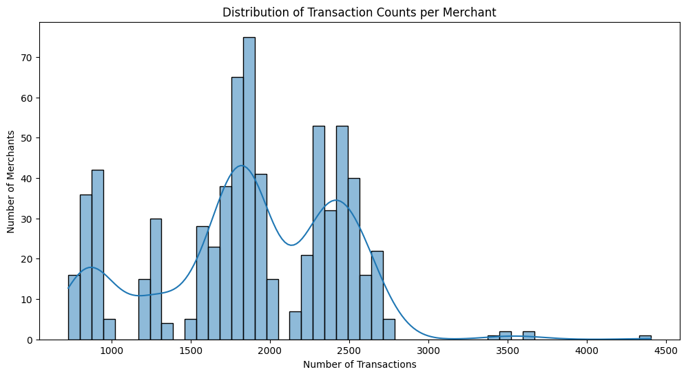

```python
# Count transactions per merchant
merchant_counts = data['merchant'].value_counts()

# Plot the distribution
plt.figure(figsize=(12, 6))
sns.histplot(merchant_counts, bins=50, kde=True)
plt.title('Distribution of Transaction Counts per Merchant')
plt.xlabel('Number of Transactions')
plt.ylabel('Number of Merchants')
plt.show()
```

Analysis of Peak 1 vs. Peak 2 Merchants:

Average Transaction Amount: Peak 1 merchants (800-1200 transactions) have a slightly higher average transaction amount (76.02) compared to Peak 2 merchants (1800-2500 transactions, 71.58). This suggests that merchants with lower transaction volumes tend to have slightly higher average spending per transaction.

Fraud Rate: Peak 2 merchants have a significantly higher fraud rate (0.0063) compared to Peak 1 merchants (0.0034). This is a crucial finding. Merchants with higher transaction volumes are more likely to be associated with fraud. Category Distribution:

Peak 1: Dominated by "grocery_net" and "travel" categories. This suggests that merchants with lower transaction volumes are more likely to be in these categories.

Peak 2: More diverse category distribution. Significant presence of "shopping_pos", "kids_pets", "entertainment", "shopping_net", and "grocery_pos".

This suggests that merchants with higher transaction volumes are more likely to be in retail and entertainment-related categories.

```python
from scipy import stats

# T-test for average transaction amount
t_stat, p_value = stats.ttest_ind(peak1_data['amt'], peak2_data['amt'])
print(f"T-test for average transaction amount: t={t_stat:.4f}, p={p_value:.4f}")
```

```
T-test for average transaction amount: t=6.7801, p=0.0000
```

The T-test results you provided are highly significant:

Interpretation of T-Test Results:

T-statistic (t = 6.7801): The t-statistic measures the difference between the means of the two groups relative to the variation within the groups. A large absolute value of the t-statistic indicates a substantial difference between the means.

P-value (p = 0.0000): A p-value of 0.0000 (or very close to zero) means that the probability of observing the data if there were no actual difference between the average transaction amounts of the two merchant peaks is extremely low. In practical terms, this means that the difference in average transaction amounts is highly statistically significant.

Implications:

The T-test results provide strong evidence that the average transaction amounts for merchants in Peak 1 and Peak 2 are significantly different. This confirms that the observed difference is not due to random chance.

While statistical significance is important, it's also essential to consider the practical significance of the difference. In this case, the average transaction amount difference was not huge, but it still was statistically different.

The average transaction amount is a relevant feature for distinguishing between merchants in the two peaks.

```python
# Chi-square test for category distribution
peak1_category_counts = peak1_data['category'].value_counts()
peak2_category_counts = peak2_data['category'].value_counts()

# Create a contingency table
contingency_table = pd.DataFrame([peak1_category_counts, peak2_category_counts]).fillna(0)

chi2_stat, p_value, _, _ = stats.chi2_contingency(contingency_table)
print(f"Chi-square test for category distribution: chi2={chi2_stat:.4f}, p={p_value:.4f}")
```

```
Chi-square test for category distribution: chi2=806207.0000, p=0.0000
```

Interpretation of Chi-Square Test Results:

Chi-square Statistic (chi2 = 806207.0000): A very large Chi-square statistic indicates a substantial difference between the observed and expected frequencies in the contingency table. In this context, it signifies that the category distributions between the two merchant peaks are very different.

P-value (p = 0.0000): A p-value of 0.0000 (or essentially zero) means that the probability of observing the data if the category distributions were the same is incredibly low. This provides overwhelming evidence to reject the null hypothesis.

Implications:

The Chi-square test results confirm that the category distributions for merchants in Peak 1 and Peak 2 are significantly different. This means that the differences we observed in the category proportions are not due to random chance.

The highly significant difference in category distributions further reinforces the idea that the two peaks represent distinct merchant segments. Merchants in different peaks tend to operate in different categories.

Merchant category is a crucial feature for distinguishing between merchants in the two peaks.

This result combined with the t test result, further shows that the two peaks are very different.

```python
# Mann-Whitney U test for transaction amounts
u_stat, p_value = stats.mannwhitneyu(peak1_data['amt'], peak2_data['amt'])
print(f"Mann-Whitney U test for transaction amounts: u={u_stat:.4f}, p={p_value:.4f}")
```

```
Mann-Whitney U test for transaction amounts: u=24486036295.5000, p=0.0000
```

```python
# # Count transactions per merchant
# merchant_counts = data['merchant'].value_counts()

# # Define peak ranges
# peak1_range = (800, 1200)
# peak2_range = (1800, 2500)

# # Function to categorize merchants
# def categorize_merchant(merchant):
#     count = merchant_counts[merchant]
#     if peak1_range[0] <= count <= peak1_range[1]:
#         return 'Peak 1'
#     elif peak2_range[0] <= count <= peak2_range[1]:
#         return 'Peak 2'
#     else:
#         return 'Other'

# # Create the 'merchant_segment' feature
# data['merchant_segment'] = data['merchant'].apply(categorize_merchant)

# # Check unique categories before one-hot encoding
# print(data['merchant_segment'].unique())

# # # One-hot encode the merchant segment.
# # data = pd.get_dummies(data, columns=['merchant_segment'], prefix='merchant_segment', drop_first=True)

# # Corrected print statement:
# print(data.columns) # print all columns to see the actual names
# print(data[['merchant_segment_Peak 2']].head()) # print a column that should exist.
```

[output not shown]

[output not shown]

```python
# Count transactions per merchant
merchant_counts = data['merchant'].value_counts()

# Define peak ranges
peak1_range = (800, 1200)
peak2_range = (1800, 2500)

# Function to categorize merchants
def categorize_merchant(merchant):
    count = merchant_counts[merchant]
    if peak1_range[0] <= count <= peak1_range[1]:
        return 'Peak 1'
    elif peak2_range[0] <= count <= peak2_range[1]:
        return 'Peak 2'
    else:
        return 'Other'

# Create the 'merchant_segment' feature
data['merchant_segment'] = data['merchant'].apply(categorize_merchant)

# One-hot encode the merchant segment.
data = pd.get_dummies(data, columns=['merchant_segment'], prefix='merchant_segment')

# Corrected print statement:
print(data[['merchant_segment_Other', 'merchant_segment_Peak 2', 'merchant_segment_Peak 1']].head())
```

```
   merchant_segment_Other  merchant_segment_Peak 2  merchant_segment_Peak 2  \
0                    True                    False                    False
1                    True                    False                    False
2                   False                     True                     True
3                    True                    False                    False
4                    True                    False                    False

   merchant_segment_Peak 1  merchant_segment_Peak 1
0                    False                    False
1                    False                    False
2                    False                    False
3                    False                    False
4                    False                    False
```

```python
data.head(3)
```

|  | Unnamed: 0 | trans_date_trans_time | cc_num | merchant | amt | first | last | gender | street | city | ... | category_shopping_pos | category_travel | merchant_segment_Peak 1 | merchant_segment_Peak 2 | merchant_segment_Other | merchant_segment_Peak 1 | merchant_segment_Peak 2 | merchant_segment_Other | merchant_segment_Peak 1 | merchant_segment_Peak 2 |
| --- | --- | --- | --- | --- | --- | --- | --- | --- | --- | --- | --- | --- | --- | --- | --- | --- | --- | --- | --- | --- | --- |
| 0 | 0 | 2019-01-01 00:00:18 | 2703186189652095 | fraud_Rippin, Kub and Mann | 4.97 | Jennifer | Banks | F | 561 Perry Cove | Moravian Falls | ... | False | False | False | False | True | False | False | True | False | False |
| 1 | 1 | 2019-01-01 00:00:44 | 630423337322 | fraud_Heller, Gutmann and Zieme | 107.23 | Stephanie | Gill | F | 43039 Riley Greens Suite 393 | Orient | ... | False | False | False | False | True | False | False | True | False | False |
| 2 | 2 | 2019-01-01 00:00:51 | 38859492057661 | fraud_Lind-Buckridge | 220.11 | Edward | Sanchez | M | 594 White Dale Suite 530 | Malad City | ... | False | False | False | True | False | False | True | False | False | True |

3 rows × 53 columns

```python
data.columns
```

```
Index(['Unnamed: 0', 'trans_date_trans_time', 'cc_num', 'merchant', 'amt',
       'first', 'last', 'gender', 'street', 'city', 'state', 'zip', 'lat',
       'long', 'city_pop', 'job', 'dob', 'trans_num', 'unix_time', 'merch_lat',
       'merch_long', 'is_fraud', 'year', 'date', 'time', 'month', 'day',
       'hour', 'dayofweek', 'time_of_day', 'num_transactions',
       'avg_transaction_amount', 'category_food_dining',
       'category_gas_transport', 'category_grocery_net',
       'category_grocery_pos', 'category_health_fitness', 'category_home',
       'category_kids_pets', 'category_misc_net', 'category_misc_pos',
       'category_personal_care', 'category_shopping_net',
       'category_shopping_pos', 'category_travel', 'merchant_segment_Peak 1',
       'merchant_segment_Peak 2', 'merchant_segment_Other',
       'merchant_segment_Peak 1', 'merchant_segment_Peak 2',
       'merchant_segment_Other', 'merchant_segment_Peak 1',
       'merchant_segment_Peak 2'],
      dtype='object')
```

```python
# Calculate transaction counts per merchant
merchant_counts = data['merchant'].value_counts()

# Define outlier thresholds (e.g., 95th percentile for high outliers)
high_threshold = merchant_counts.quantile(0.95)

# Identify high outliers
high_outliers = merchant_counts[merchant_counts > high_threshold]

# Print high outliers
print("High Outlier Merchants:")
print(high_outliers)

# Define outlier thresholds (e.g., 5th percentile for low outliers)
low_threshold = merchant_counts.quantile(0.05)

# Identify low outliers
low_outliers = merchant_counts[merchant_counts < low_threshold]

# Print low outliers
print("\nLow Outlier Merchants:")
print(low_outliers)

# Example of grouping outliers into a separate category
def categorize_merchant_outlier(merchant):
    count = merchant_counts[merchant]
    if merchant in high_outliers:
        return 'High Volume Outlier'
    elif merchant in low_outliers:
        return 'Low Volume Outlier'
    else:
        return 'Normal'

# Create the 'merchant_outlier' feature
data['merchant_outlier'] = data['merchant'].apply(categorize_merchant_outlier)

# One hot encode the merchant_outlier column.
data = pd.get_dummies(data, columns=['merchant_outlier'], prefix='merchant_outlier')

print(data[['merchant', 'merchant_outlier_High Volume Outlier', 'merchant_outlier_Low Volume Outlier']].head())
```

```
High Outlier Merchants:
merchant
fraud_Kilback LLC                              4403
fraud_Cormier LLC                              3649
fraud_Schumm PLC                               3634
fraud_Kuhn LLC                                 3510
fraud_Boyer PLC                                3493
fraud_Dickinson Ltd                            3434
fraud_Cummerata-Jones                          2736
fraud_Kutch LLC                                2734
fraud_Olson, Becker and Koch                   2723
fraud_Stroman, Hudson and Erdman               2721
fraud_Rodriguez Group                          2716
fraud_Jenkins, Hauck and Friesen               2705
fraud_Erdman-Kertzmann                         2705
fraud_Kling Inc                                2687
fraud_Connelly, Reichert and Fritsch           2684
fraud_Friesen-Stamm                            2680
fraud_Prohaska-Murray                          2679
fraud_Huels-Hahn                               2678
fraud_Berge LLC                                2677
fraud_Bartoletti-Wunsch                        2676
fraud_Christiansen, Goyette and Schamberger    2676
fraud_Corwin-Collins                           2675
fraud_Eichmann, Bogan and Rodriguez            2658
fraud_Greenholt, Jacobi and Gleason            2656
fraud_Bins-Rice                                2655
fraud_Brekke and Sons                          2653
fraud_Schmitt Inc                              2651
fraud_Mraz-Herzog                              2646
fraud_Tillman, Dickinson and Labadie           2645
fraud_Kuvalis Ltd                              2643
fraud_Torp-Labadie                             2642
fraud_Emard Inc                                2641
fraud_Bernhard Inc                             2639
fraud_Parisian and Sons                        2637
fraud_Luettgen PLC                             2630
Name: count, dtype: int64

Low Outlier Merchants:
```

[output cut: 34 more lines]

```
fraud_Hahn, Douglas and Schowalter       727
Name: count, dtype: int64
                             merchant  merchant_outlier_High Volume Outlier  \
0          fraud_Rippin, Kub and Mann                                 False
1     fraud_Heller, Gutmann and Zieme                                 False
2                fraud_Lind-Buckridge                                 False
3  fraud_Kutch, Hermiston and Farrell                                 False
4                 fraud_Keeling-Crist                                 False

   merchant_outlier_Low Volume Outlier
0                                False
1                                False
2                                False
3                                False
4                                False
```

This output is showing the merchants that are considered "high outliers" based on their transaction counts.

Analysis of High Outlier Merchants:

The list shows the names of the merchants that have unusually high transaction counts compared to the rest of the merchants in the dataset. The numbers next to the merchant names represent the total number of transactions associated with each merchant. "fraud_Kilback LLC" at the Top: As expected, "fraud_Kilback LLC" is at the top of the list with the highest transaction count (4403), confirming our earlier observations.

Several other merchants also have high transaction counts, ranging from around 2600 to 3600. These merchants are also potential areas of interest for fraud detection.

```python
# Calculate fraud rates for high-outlier merchants
high_outlier_fraud_rates = data[data['merchant'].isin(high_outliers.index)].groupby('merchant')['is_fraud'].mean()

# Print fraud rates
print("Fraud Rates for High Outlier Merchants:")
print(high_outlier_fraud_rates)
```

```
Fraud Rates for High Outlier Merchants:
merchant
fraud_Bartoletti-Wunsch                        0.005605
fraud_Berge LLC                                0.003362
fraud_Bernhard Inc                             0.005684
fraud_Bins-Rice                                0.005273
fraud_Boyer PLC                                0.011451
fraud_Brekke and Sons                          0.003769
fraud_Christiansen, Goyette and Schamberger    0.003737
fraud_Connelly, Reichert and Fritsch           0.004471
fraud_Cormier LLC                              0.013154
fraud_Corwin-Collins                           0.004860
fraud_Cummerata-Jones                          0.004386
fraud_Dickinson Ltd                            0.002330
fraud_Eichmann, Bogan and Rodriguez            0.006396
fraud_Emard Inc                                0.004165
fraud_Erdman-Kertzmann                         0.005176
fraud_Friesen-Stamm                            0.005224
fraud_Greenholt, Jacobi and Gleason            0.006024
fraud_Huels-Hahn                               0.003734
fraud_Jenkins, Hauck and Friesen               0.005545
fraud_Kilback LLC                              0.010675
fraud_Kling Inc                                0.003722
fraud_Kuhn LLC                                 0.012536
fraud_Kutch LLC                                0.005486
fraud_Kuvalis Ltd                              0.004919
fraud_Luettgen PLC                             0.004563
fraud_Mraz-Herzog                              0.003779
fraud_Olson, Becker and Koch                   0.004040
fraud_Parisian and Sons                        0.006447
fraud_Prohaska-Murray                          0.008212
fraud_Rodriguez Group                          0.004050
fraud_Schmitt Inc                              0.006035
fraud_Schumm PLC                               0.008531
fraud_Stroman, Hudson and Erdman               0.003675
fraud_Tillman, Dickinson and Labadie           0.005293
fraud_Torp-Labadie                             0.003785
Name: is_fraud, dtype: float64
```

Analysis of Fraud Rates for High Outlier Merchants:

There's a noticeable variation in fraud rates among these high-volume merchants. Some merchants have relatively low fraud rates (e.g., "fraud_Dickinson Ltd" with 0.002330), while others have significantly higher rates (e.g., "fraud_Cormier LLC" with 0.013154, "fraud_Kuhn LLC" with 0.012536).

"fraud_Kilback LLC" has a fraud rate of 0.010675, which is relatively high. This confirms our earlier suspicion that this merchant is associated with a significant amount of fraudulent activity.

Merchants like "fraud_Cormier LLC" and "fraud_Kuhn LLC" have fraud rates exceeding 1%, which is considerably higher than the average fraud rate in many datasets. These merchants warrant close attention.

Key Implications:

These results highlight the importance of targeted fraud detection efforts.

```python
# Calculate overall fraud rate
overall_fraud_rate = data['is_fraud'].mean()
print(f"Overall Fraud Rate: {overall_fraud_rate:.4f}")
```

```
Overall Fraud Rate: 0.0058
```

Interpretation of Overall Fraud Rate (0.58%):

This is the average fraud rate across all transactions in your dataset. It represents the overall risk of fraud in your dataset.

Implications:

Merchants like "fraud_Cormier LLC" (1.31%), "fraud_Kuhn LLC" (1.25%), and "fraud_Kilback LLC" (1.07%) have fraud rates substantially higher than the overall rate. This confirms that these merchants are indeed high-risk and require focused attention.

Even merchants with fraud rates slightly above 0.58% might still be considered relatively high-risk compared to the average.

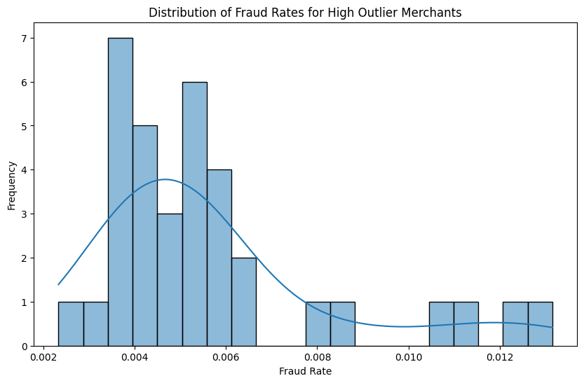

```python
# Visualize distribution of fraud rates
plt.figure(figsize=(10, 6))
sns.histplot(high_outlier_fraud_rates, bins=20, kde=True)
plt.title('Distribution of Fraud Rates for High Outlier Merchants')
plt.xlabel('Fraud Rate')
plt.ylabel('Frequency')
plt.show()
```

The distribution is right-skewed, meaning that most high outlier merchants have relatively low fraud rates, while a few have significantly higher rates.

A large number of merchants have fraud rates between approximately 0.003 and 0.006. This is the most concentrated area of the graph.

The long tail extending towards higher fraud rates (0.010 to 0.013) indicates the presence of a few merchants with exceptionally high fraud rates.

The merchants in the long tail can be considered outliers in terms of fraud rates.

The Kernel Density Estimate (KDE) curve smooths the distribution and highlights the skewness and the presence of the long tail. Key Implications:

The visualization clearly shows that some high outlier merchants have considerably higher fraud rates than the majority. These merchants require special attention.

The distribution reinforces the need for targeted fraud detection efforts. Focusing on the high-risk merchants in the long tail can significantly improve fraud detection.

Even among high-volume merchants, there's a wide variation in fraud risk.

The merchant name is a very strong feature. The fraud rate of the merchant is also a very strong feature.

```python
# Identify high-risk merchants (e.g., fraud rate > 0.01)
high_risk_merchants = high_outlier_fraud_rates[high_outlier_fraud_rates > 0.01].index

# Investigate characteristics of high-risk merchants
high_risk_data = data[data['merchant'].isin(high_risk_merchants)]

# Example: Analyze category distribution
category_distribution = high_risk_data['category'].value_counts(normalize=True)
print("\nCategory Distribution for High-Risk Merchants:")
print(category_distribution)

# Example: Analyze time of day distribution
time_distribution = high_risk_data['trans_date_trans_time'].dt.hour.value_counts(normalize=True).sort_index()
print("\nTime of Day Distribution for High-Risk Merchants:")
print(time_distribution)

# Example: Analyze transaction amount distribution
print("\nTransaction Amount Distribution for High-Risk Merchants:")
print(high_risk_data['amt'].describe())

# Example: Analyze geographical distribution
print("\nGeographical Distribution for High-Risk Merchants:")
print(high_risk_data[['lat', 'long']].describe())
```

```
Category Distribution for High-Risk Merchants:
category
shopping_net      0.257522
grocery_pos       0.168117
shopping_pos      0.151976
food_dining       0.124344
health_fitness    0.112255
misc_pos          0.104616
misc_net          0.081169
Name: proportion, dtype: float64

Time of Day Distribution for High-Risk Merchants:
trans_date_trans_time
0     0.043241
1     0.036998
2     0.038990
3     0.038393
4     0.040053
5     0.041448
6     0.039854
7     0.040319
8     0.038858
9     0.039854
10    0.039655
11    0.038858
12    0.043175
13    0.045035
14    0.043042
15    0.043109
16    0.043241
17    0.042444
18    0.042976
19    0.044968
20    0.043109
21    0.042312
22    0.044105
23    0.045965
Name: proportion, dtype: float64

Transaction Amount Distribution for High-Risk Merchants:
count    15055.000000
mean        79.913393
std        162.181735
min          1.000000
25%          6.470000
50%         33.560000
75%         97.620000
max       3887.500000
Name: amt, dtype: float64

Geographical Distribution for High-Risk Merchants:
                lat          long
count  15055.000000  15055.000000
mean      38.499925    -90.140073
std        5.086458     13.566232
min       20.027100   -165.672300
25%       34.509100    -96.727000
50%       39.354300    -87.349000
75%       41.846700    -80.185900
max       66.693300    -67.950300
```

```python
# Number of fraudulent transactions from "fraud_Kilback LLC"
fraud_kilback_count = len(data[(data['merchant'] == 'fraud_Kilback LLC') & (data['is_fraud'] == 1)])

# Total number of transactions from "fraud_Kilback LLC"
total_kilback_count = len(data[data['merchant'] == 'fraud_Kilback LLC'])

# Print the results
print(f"Number of fraudulent transactions from fraud_Kilback LLC: {fraud_kilback_count}")
print(f"Total number of transactions from fraud_Kilback LLC: {total_kilback_count}")

# Calculate the percentage of fraud
if total_kilback_count > 0:
    fraud_percentage = (fraud_kilback_count / total_kilback_count) * 100
    print(f"Percentage of fraudulent transactions from fraud_Kilback LLC: {fraud_percentage:.2f}%")
else:
    print("No transactions found for fraud_Kilback LLC.")
```

```
Number of fraudulent transactions from fraud_Kilback LLC: 47
Total number of transactions from fraud_Kilback LLC: 4403
Percentage of fraudulent transactions from fraud_Kilback LLC: 1.07%
```

is_fraud Time (day, hour) Transaction amount Credit card number Merchant Category Geographic location

```python
data['category'].describe()
```

```
count           1296675
unique               14
top       gas_transport
freq             131659
Name: category, dtype: object
```

```
Fraud transactions per category:
category_food_dining        151
category_gas_transport      618
category_grocery_net        134
category_grocery_pos       1743
category_health_fitness     133
category_home               198
category_kids_pets          239
category_misc_net           915
category_misc_pos           250
category_personal_care      220
category_shopping_net      1713
category_shopping_pos       843
category_travel             116
dtype: int64

Percentage of fraud transactions per category:
category_food_dining       0.165098
category_gas_transport     0.469394
category_grocery_net       0.294817
category_grocery_pos       1.409761
category_health_fitness    0.154869
category_home              0.160825
category_kids_pets         0.211439
category_misc_net          1.445795
category_misc_pos          0.313853
category_personal_care     0.242403
category_shopping_net      1.756149
category_shopping_pos      0.722538
category_travel            0.286370
dtype: float64
```

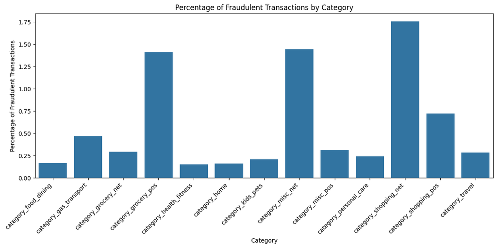

```python
# One-hot encoding of the 'category' column
data = pd.get_dummies(data, columns=['category'], prefix='category', drop_first=True)

# Count of fraud transactions per category
fraud_by_category = data[data['is_fraud'] == 1][[col for col in data if col.startswith('category_')]].sum()
print("Fraud transactions per category:")
print(fraud_by_category)

# Percentage of fraud transactions per category
total_by_category = data[[col for col in data if col.startswith('category_')]].sum()
fraud_percentage_category = (fraud_by_category / total_by_category) * 100
print("\nPercentage of fraud transactions per category:")
print(fraud_percentage_category)

# Plotting the percentage of fraud transactions per category.
plt.figure(figsize=(12, 6))
sns.barplot(x=fraud_percentage_category.index, y=fraud_percentage_category.values)
plt.title('Percentage of Fraudulent Transactions by Category')
plt.xlabel('Category')
plt.ylabel('Percentage of Fraudulent Transactions')
plt.xticks(rotation=45, ha='right')  # Rotate x-axis labels for readability
plt.tight_layout() # prevents labels from being cut off.
plt.show()
```

Raw counts alone don't consider the overall volume of transactions within each category. A category with a high count might simply have a high volume of transactions in general.

The percentages provide a more accurate picture of fraud risk. Even if a category has a moderate number of fraudulent transactions, its risk is higher if it also has a low volume of total transactions.

The percentage data is more valuable for assessing fraud risk. It allows you to prioritize categories with higher relative fraud rates.

For example, even though "category_gas_transport" has a higher raw fraud count than "category_food_dining", the percentage of fraud in "category_food_dining" is lower.

```python
data.columns
```

```
Index(['Unnamed: 0', 'trans_date_trans_time', 'cc_num', 'merchant', 'amt',
       'first', 'last', 'gender', 'street', 'city', 'state', 'zip', 'lat',
       'long', 'city_pop', 'job', 'dob', 'trans_num', 'unix_time', 'merch_lat',
       'merch_long', 'is_fraud', 'year', 'date', 'time', 'month', 'day',
       'hour', 'dayofweek', 'time_of_day', 'num_transactions',
       'avg_transaction_amount', 'category_food_dining',
       'category_gas_transport', 'category_grocery_net',
       'category_grocery_pos', 'category_health_fitness', 'category_home',
       'category_kids_pets', 'category_misc_net', 'category_misc_pos',
       'category_personal_care', 'category_shopping_net',
       'category_shopping_pos', 'category_travel'],
      dtype='object')
```

```python
data['amt'].info()
```

```
<class 'pandas.core.series.Series'>
RangeIndex: 1296675 entries, 0 to 1296674
Series name: amt
Non-Null Count    Dtype
--------------    -----
1296675 non-null  float64
dtypes: float64(1)
memory usage: 9.9 MB
```

```python
data['amt'].value_counts()
```

```
amt
1.14       542
1.04       538
1.25       535
1.02       533
1.01       523
          ...
454.46       1
872.14       1
405.03       1
1060.31      1
1078.51      1
Name: count, Length: 52928, dtype: int64
```

```python
data['amt'].unique()
```

```
array([  4.97, 107.23, 220.11, ..., 754.81, 374.71, 255.52],
      shape=(52928,))
```

```python
data.head()
```

|  | Unnamed: 0 | trans_date_trans_time | cc_num | merchant | amt | first | last | gender | street | city | ... | category_grocery_pos | category_health_fitness | category_home | category_kids_pets | category_misc_net | category_misc_pos | category_personal_care | category_shopping_net | category_shopping_pos | category_travel |
| --- | --- | --- | --- | --- | --- | --- | --- | --- | --- | --- | --- | --- | --- | --- | --- | --- | --- | --- | --- | --- | --- |
| 0 | 0 | 2019-01-01 00:00:18 | 2703186189652095 | fraud_Rippin, Kub and Mann | 4.97 | Jennifer | Banks | F | 561 Perry Cove | Moravian Falls | ... | False | False | False | False | True | False | False | False | False | False |
| 1 | 1 | 2019-01-01 00:00:44 | 630423337322 | fraud_Heller, Gutmann and Zieme | 107.23 | Stephanie | Gill | F | 43039 Riley Greens Suite 393 | Orient | ... | True | False | False | False | False | False | False | False | False | False |
| 2 | 2 | 2019-01-01 00:00:51 | 38859492057661 | fraud_Lind-Buckridge | 220.11 | Edward | Sanchez | M | 594 White Dale Suite 530 | Malad City | ... | False | False | False | False | False | False | False | False | False | False |
| 3 | 3 | 2019-01-01 00:01:16 | 3534093764340240 | fraud_Kutch, Hermiston and Farrell | 45.00 | Jeremy | White | M | 9443 Cynthia Court Apt. 038 | Boulder | ... | False | False | False | False | False | False | False | False | False | False |
| 4 | 4 | 2019-01-01 00:03:06 | 375534208663984 | fraud_Keeling-Crist | 41.96 | Tyler | Garcia | M | 408 Bradley Rest | Doe Hill | ... | False | False | False | False | False | True | False | False | False | False |

5 rows × 45 columns

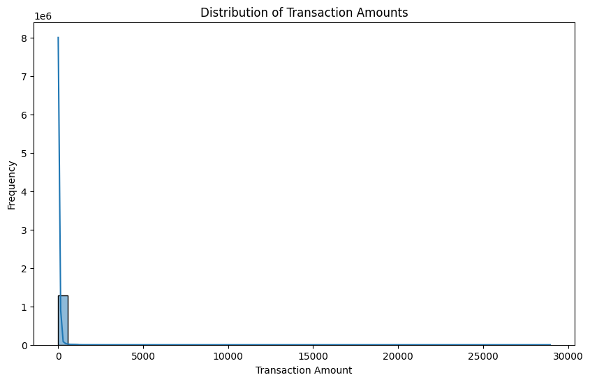

```python
# Histogram of transaction amounts
plt.figure(figsize=(10, 6))
sns.histplot(data['amt'], bins=50, kde=True)
plt.title('Distribution of Transaction Amounts')
plt.xlabel('Transaction Amount')
plt.ylabel('Frequency')
plt.show()
```

Extreme Skewness: The histogram shows an extremely skewed distribution. The vast majority of the data points are concentrated at the very low end of the transaction amount range (close to zero). This is evident from the extremely tall bar on the far left of the graph.

Long Tail: The distribution has a very long tail extending towards higher transaction amounts. This means that while most transactions are small, there are a few transactions with very large amounts.

Outliers: The long tail suggests the presence of outliers—transactions with unusually high amounts. These outliers are so far from the main cluster of data that they compress the visualization of the bulk of the data.

Data Characteristics: This type of distribution is common in financial data, where most transactions are small, but occasional large transactions occur (e.g., large purchases, transfers, etc.).

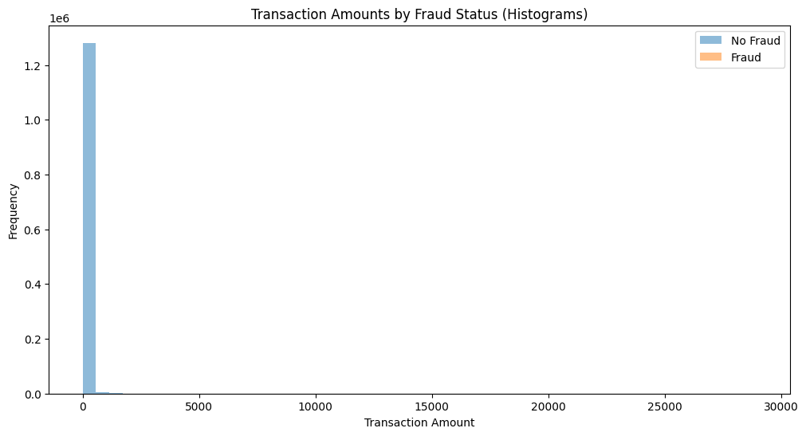

```python
# Histogram for non-fraudulent transactions
plt.figure(figsize=(12, 6))
plt.hist(data[data['is_fraud'] == 0]['amt'], bins=50, alpha=0.5, label='No Fraud')

# Histogram for fraudulent transactions
plt.hist(data[data['is_fraud'] == 1]['amt'], bins=50, alpha=0.5, label='Fraud')

plt.title('Transaction Amounts by Fraud Status (Histograms)')
plt.xlabel('Transaction Amount')
plt.ylabel('Frequency')
plt.legend(loc='upper right')
plt.show()
```

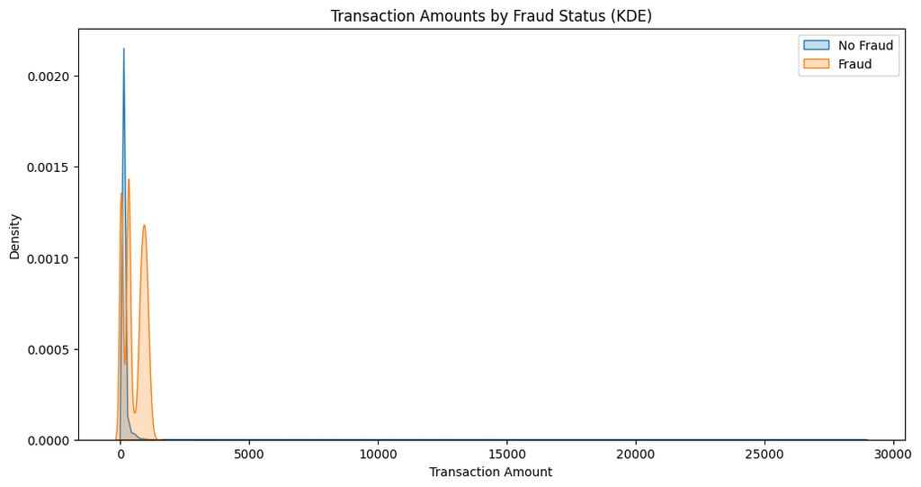

```python
plt.figure(figsize=(12, 6))
sns.kdeplot(data[data['is_fraud'] == 0]['amt'], label='No Fraud', fill=True)
sns.kdeplot(data[data['is_fraud'] == 1]['amt'], label='Fraud', fill=True)

plt.title('Transaction Amounts by Fraud Status (KDE)')
plt.xlabel('Transaction Amount')
plt.ylabel('Density')
plt.legend(loc='upper right')
plt.show()
```

```
Number of Outliers: 12967

Outlier Summary Statistics:
count    12967.000000
mean      1055.154232
std       1071.203127
min        546.000000
25%        666.930000
50%        844.230000
75%       1055.520000
max      28948.900000
Name: amt, dtype: float64
```

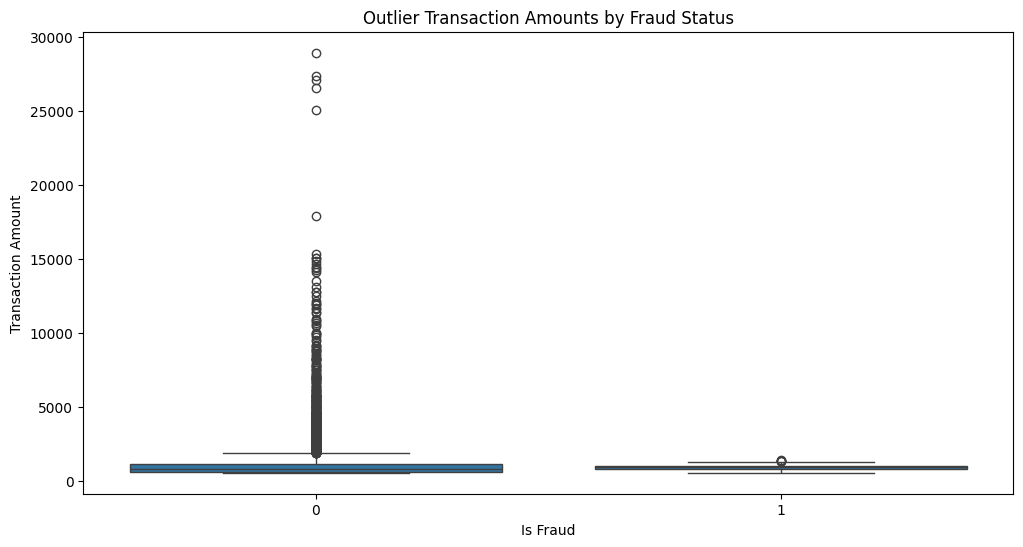

```
Outlier Category Distribution:
category
shopping_net      0.317421
shopping_pos      0.305699
misc_net          0.161410
travel            0.109123
misc_pos          0.096784
entertainment     0.008329
food_dining       0.000771
kids_pets         0.000231
health_fitness    0.000154
home              0.000077
Name: proportion, dtype: float64

Outlier Time of Day Distribution:
trans_date_trans_time
0     0.029459
1     0.031310
2     0.032081
3     0.029614
4     0.022442
5     0.021670
6     0.019588
7     0.021516
8     0.021593
9     0.019974
10    0.019434
11    0.022904
12    0.040719
13    0.044498
14    0.043341
15    0.042492
16    0.046657
17    0.043572
18    0.043264
19    0.043572
20    0.042415
21    0.044420
22    0.141205
23    0.132259
```

[output cut: 48 more lines]

```
    merchant_outlier_High Volume Outlier merchant_outlier_Low Volume Outlier  \
138                                False                               False
232                                False                               False
296                                False                               False
511                                False                               False
723                                False                               False

     merchant_outlier_Normal
138                     True
232                     True
296                     True
511                     True
723                     True

[5 rows x 37 columns]
```

```python
# Define a threshold for outliers (e.g., above 99th percentile)
threshold = data['amt'].quantile(0.99)

# Identify outliers
outliers = data[data['amt'] > threshold]

# Investigate outliers
print("Number of Outliers:", len(outliers))
print("\nOutlier Summary Statistics:")
print(outliers['amt'].describe())

# Visualize outliers
plt.figure(figsize=(12, 6))
sns.boxplot(x='is_fraud', y='amt', data=outliers)
plt.title('Outlier Transaction Amounts by Fraud Status')
plt.xlabel('Is Fraud')
plt.ylabel('Transaction Amount')
plt.show()

# Investigate other characteristics of outliers
print("\nOutlier Category Distribution:")
print(outliers['category'].value_counts(normalize=True))

print("\nOutlier Time of Day Distribution:")
print(outliers['trans_date_trans_time'].dt.hour.value_counts(normalize=True).sort_index())

print("\nOutlier Merchant Distribution:")
print(outliers['merchant'].value_counts().head(10)) # Top 10 merchants

# Investigate if outliers are fraudulent.
print("\nPercentage of fraudulent transactions in outliers:")
print(outliers['is_fraud'].mean())

# Investigate the actual transactions that are outliers.
print("\nExample of Outlier Transactions:")
print(outliers.head())
```

Analysis of Outlier Information:

This indicates that there are 12,967 transactions identified as outliers based on your chosen threshold (presumably the 99th percentile). This is about 1% of the total dataset.

Outlier Summary Statistics: count: 12967.000000 - Confirms the number of outliers. mean: 1055.154232 - The average transaction amount for outliers is approximately $1055. std: 1071.203127 - The standard deviation shows a wide spread of transaction amounts among outliers. min: 546.000000 - The minimum outlier amount is $546. 25%: 666.930000 - 25% of outliers are below $666.93. 50%: 844.230000 - The median outlier amount is $844.23. 75%: 1055.520000 - 75% of outliers are below $1055.52. max: 28948.900000 - The maximum outlier amount is a very large $28,948.90.

Box Plot: The box plot visually shows the distribution of outlier transaction amounts by fraud status (is_fraud). "0" (No Fraud): Shows a very large amount of high value outliers. Shows a very large amount of values in general. "1" (Fraud): Shows a very small amount of outliers. Shows that the fraud outliers are of a much lower value, than the non fraud outliers.

Key Observations and Implications:

The box plot highlights a clear difference in the distribution of outlier amounts between fraudulent and non-fraudulent transactions. Non-fraudulent outliers tend to have much higher transaction amounts.

```python
# Investigate merchants associated with outlier transactions
outlier_merchant_counts = outliers['merchant'].value_counts()

# Print the top 20 merchants associated with outliers
print("Top 20 Merchants Associated with Outlier Transactions:")
print(outlier_merchant_counts.head(20))

# Calculate the fraud rate for each merchant associated with outliers
outlier_merchant_fraud_rates = outliers.groupby('merchant')['is_fraud'].mean()

# Print the fraud rates for the top 20 merchants
print("\nFraud Rates for Top 20 Merchants Associated with Outlier Transactions:")
print(outlier_merchant_fraud_rates[outlier_merchant_counts.index[:20]])  # Match the index of the top 20

# Investigate the category distribution for the top outlier merchants.
print("\nCategory distribution for the top outlier merchants:")
for merchant in outlier_merchant_counts.index[:5]: # just the top 5 to avoid too much output.
    print(f"\nMerchant: {merchant}")
    print(outliers[outliers['merchant'] == merchant]['category'].value_counts(normalize=True))
```

```
Top 20 Merchants Associated with Outlier Transactions:
merchant
fraud_Kuhn LLC                            118
fraud_Schmeler, Bashirian and Price       107
fraud_Boyer PLC                           102
fraud_Lemke-Gutmann                        98
fraud_Price Inc                            98
fraud_Terry-Huel                           97
fraud_Gottlieb, Considine and Schultz      96
fraud_Kozey-Boehm                          95
fraud_Quitzon, Green and Bashirian         94
fraud_Greenholt, O'Hara and Balistreri     93
fraud_Labadie, Treutel and Bode            92
fraud_Jewess LLC                           92
fraud_Mohr Inc                             92
fraud_Pacocha-Bauch                        91
fraud_Zboncak, Rowe and Murazik            90
fraud_Kuhic, Bins and Pfeffer              90
fraud_Stanton, Jakubowski and Baumbach     90
fraud_Langworth, Boehm and Gulgowski       89
fraud_Pfeffer and Sons                     89
fraud_Macejkovic-Lesch                     89
Name: count, dtype: int64

Fraud Rates for Top 20 Merchants Associated with Outlier Transactions:
merchant
fraud_Kuhn LLC                            0.372881
fraud_Schmeler, Bashirian and Price       0.383178
fraud_Boyer PLC                           0.362745
fraud_Lemke-Gutmann                       0.326531
fraud_Price Inc                           0.387755
fraud_Terry-Huel                          0.443299
fraud_Gottlieb, Considine and Schultz     0.364583
fraud_Kozey-Boehm                         0.505263
fraud_Quitzon, Green and Bashirian        0.265957
fraud_Greenholt, O'Hara and Balistreri    0.387097
fraud_Labadie, Treutel and Bode           0.380435
fraud_Jewess LLC                          0.206522
fraud_Mohr Inc                            0.206522
fraud_Pacocha-Bauch                       0.197802
```

[output cut: 21 more lines]

```
Merchant: fraud_Boyer PLC
category
shopping_net    0.745098
misc_pos        0.254902
Name: proportion, dtype: float64

Merchant: fraud_Lemke-Gutmann
category
shopping_net    1.0
Name: proportion, dtype: float64

Merchant: fraud_Price Inc
category
shopping_net    1.0
Name: proportion, dtype: float64
```

Certain merchants are consistently associated with a high number of outlier transactions. Fraud rates vary among these merchants. Merchant-specific category distributions can provide insights into the types of high-value transactions.

```python
data['is_fraud'].value_counts()
```

```
is_fraud
0    1289169
1       7506
Name: count, dtype: int64
```

```python
len(data)
```

```
1296675
```

7506/ 1296675 = 0.0057 the dataset is highly imbalanced.

A balanced dataset would have a ratio closer to 1, indicating that the classes are represented in roughly equal proportions. In this case, the significant difference between the number of instances in the target class (0.57%) and the other class(es) (99.43%) indicates a strong imbalance.

Leaning towards SMOTE (Synthetic Minority Over-sampling Technique) as a starting point. Here's why:

High Imbalance: The dataset has a significant class imbalance, making oversampling a strong candidate.

Dataset Size: You have a large dataset, so oversampling is computationally feasible.

SMOTE's Effectiveness: SMOTE is a popular and generally effective technique for addressing class imbalance. It generates synthetic samples of the minority class, which can help improve the model's ability to detect fraudulent transactions.

Avoiding Information Loss: Oversampling with SMOTE helps to avoid the significant information loss that can occur with undersampling.

```python
from sklearn.model_selection import train_test_split
from sklearn.ensemble import RandomForestClassifier
from sklearn.metrics import precision_score, recall_score, f1_score, roc_auc_score
from imblearn.over_sampling import SMOTE

# Separate features (X) and target (y)
X = data.drop('is_fraud', axis=1)  # Drop the target variable
y = data['is_fraud']

# Select only numeric columns for SMOTE (SMOTE cannot handle categorical)
numeric_X = X.select_dtypes(include=['number'])

# Split data into training and testing sets
X_train, X_test, y_train, y_test = train_test_split(numeric_X, y, test_size=0.3, random_state=42)

# Apply SMOTE to the training data
smote = SMOTE(random_state=42)
X_train_resampled, y_train_resampled = smote.fit_resample(X_train, y_train)

# Train a Random Forest Classifier
model = RandomForestClassifier(random_state=42)
model.fit(X_train_resampled, y_train_resampled)

# Make predictions on the test set
y_pred = model.predict(X_test)
y_pred_proba = model.predict_proba(X_test)[:, 1]  # Probabilities for AUC-ROC

# Evaluate the model
precision = precision_score(y_test, y_pred)
recall = recall_score(y_test, y_pred)
f1 = f1_score(y_test, y_pred)
auc_roc = roc_auc_score(y_test, y_pred_proba)

# Print the evaluation metrics
print(f"Precision: {precision:.4f}")
print(f"Recall: {recall:.4f}")
print(f"F1-score: {f1:.4f}")
print(f"AUC-ROC: {auc_roc:.4f}")
```

```
Precision: 0.6763
Recall: 0.8184
F1-score: 0.7406
AUC-ROC: 0.9867
```

Precision: 0.6763

This means that 67.63% of the transactions predicted as fraudulent by your model were actually fraudulent. In other words, out of all the transactions your model flagged as fraud, 67.63% were correct.

Recall: 0.8184

This means that your model correctly identified 81.84% of all actual fraudulent transactions in the dataset. In other words, it didn't miss many actual fraud cases.

F1-score: 0.7406

The F1-score is the harmonic mean of precision and recall. It provides a balanced measure of the model's accuracy. An F1-score of 0.7406 indicates a good balance between precision and recall.

AUC-ROC: 0.9867

The AUC-ROC (Area Under the Receiver Operating Characteristic curve) measures the model's ability to distinguish between fraudulent and non-fraudulent transactions. An AUC-ROC of 0.9867 is very high, indicating that your model has excellent discriminatory power.